# Genome-wide methylation analysis report

# Genome-wide methylation analysis report

- study: Pleural cfDNAm analysis of cg05575921variable
- author: Paul Yousefi
- date: 08 October, 2026

## Parameters

```
## $sig.threshold
## [1] 2.121143e-07
##
## $max.plots
## [1] 10
##
## $qq.inflation.method
## [1] "median"
##
## $practical.threshold
## [1] 1.304326e-08
```

## Sample characteristics

For continuous or ordinal variables, the “mean” column provides the mean and the “sd/%” column the standard deviation of the variable. For categorical variables, the “mean” column provides the number of samples with the given “value” and the “sd/%” column the percentage of samples with the given “value”.

| variable | value | mean | sd.. |
| --- | --- | --- | --- |
| cg05575921 |  | 0.7150795 | 0.1873398 |
| sv1 |  | -8.992565e-19 | 0.0571662 |
| sv2 |  | 7.901962e-19 | 0.0571662 |
| sv3 |  | -3.103396e-19 | 0.0571662 |
| sv4 |  | 3.308227e-18 | 0.0571662 |
| sv5 |  | 3.108164e-18 | 0.0571662 |
| sv6 |  | 2.620251e-18 | 0.0571662 |
| sv7 |  | 6.272723e-18 | 0.0571662 |
| sv8 |  | 1.09103e-15 | 0.0571662 |
| sv9 |  | 3.765489e-14 | 0.0571662 |
| sv10 |  | 6.039341e-13 | 0.0571662 |

## Covariate associations

### Covariate sv1

statistics

| var1 | var2 | F | p-value | R | p-value |
| --- | --- | --- | --- | --- | --- |
| cg05575921 | sv1 | 5.074321 | 0.0249934 | -0.0197219 | 0.7305672 |

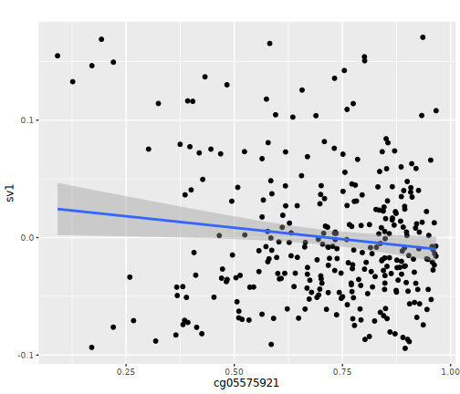

### Covariate sv2

statistics

| var1 | var2 | F | p-value | R | p-value |
| --- | --- | --- | --- | --- | --- |
| cg05575921 | sv2 | 29.80735 | 1e-07 | -0.2570623 | 5.4e-06 |

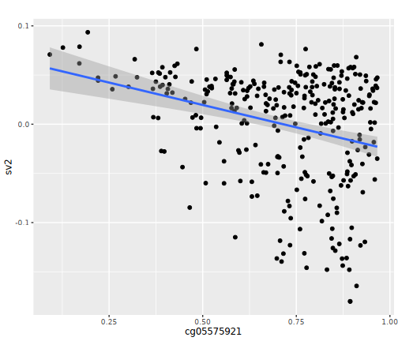

### Covariate sv3

statistics

| var1 | var2 | F | p-value | R | p-value |
| --- | --- | --- | --- | --- | --- |
| cg05575921 | sv3 | 29.01275 | 1e-07 | 0.2407956 | 2.12e-05 |

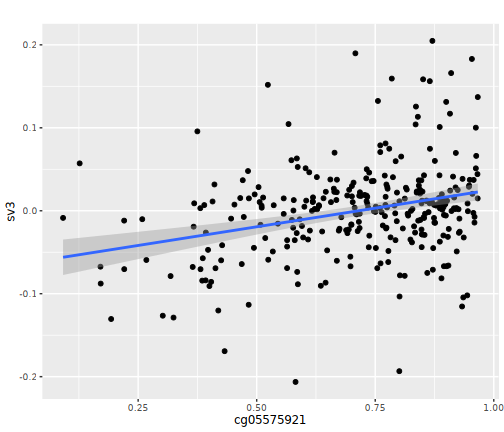

### Covariate sv4

statistics

| var1 | var2 | F | p-value | R | p-value |
| --- | --- | --- | --- | --- | --- |
| cg05575921 | sv4 | 0.2830839 | 0.5950743 | -0.0239721 | 0.6755077 |

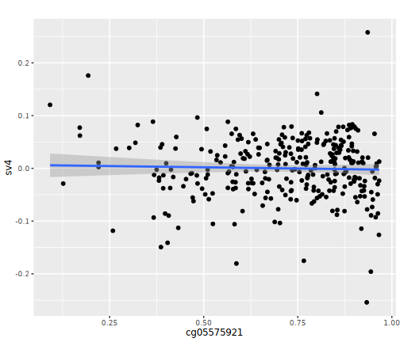

### Covariate sv5

statistics

| var1 | var2 | F | p-value | R | p-value |
| --- | --- | --- | --- | --- | --- |
| cg05575921 | sv5 | 2.892339 | 0.0900209 | 0.1565952 | 0.0060129 |

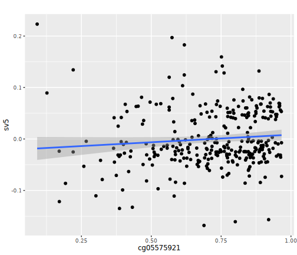

### Covariate sv6

statistics

| var1 | var2 | F | p-value | R | p-value |
| --- | --- | --- | --- | --- | --- |
| cg05575921 | sv6 | 2.288136 | 0.1314019 | 0.0468837 | 0.4128209 |

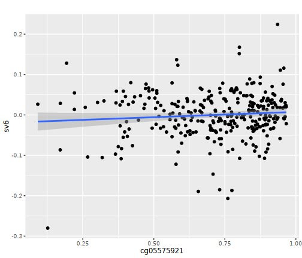

### Covariate sv7

statistics

| var1 | var2 | F | p-value | R | p-value |
| --- | --- | --- | --- | --- | --- |
| cg05575921 | sv7 | 2.749662 | 0.0983031 | 0.1018162 | 0.0748723 |

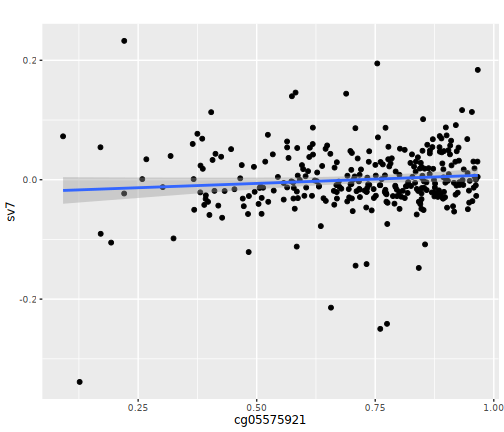

### Covariate sv8

statistics

| var1 | var2 | F | p-value | R | p-value |
| --- | --- | --- | --- | --- | --- |
| cg05575921 | sv8 | 19.92808 | 1.13e-05 | -0.2154424 | 0.0001472 |

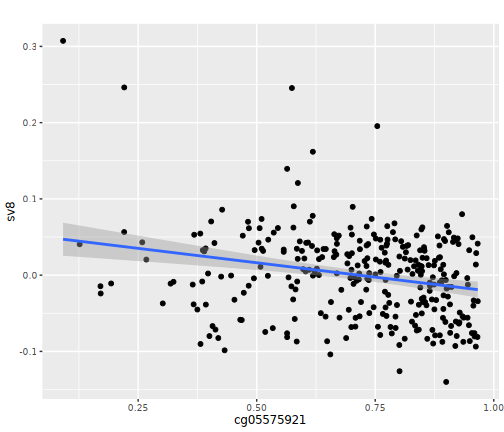

### Covariate sv9

statistics

| var1 | var2 | F | p-value | R | p-value |
| --- | --- | --- | --- | --- | --- |
| cg05575921 | sv9 | 0.116343 | 0.73327 | 0.0516582 | 0.366835 |

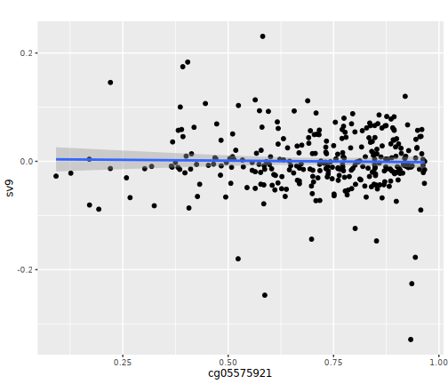

### Covariate sv10

statistics

| var1 | var2 | F | p-value | R | p-value |
| --- | --- | --- | --- | --- | --- |
| cg05575921 | sv10 | 1.204823 | 0.2732257 | -0.0677175 | 0.236654 |

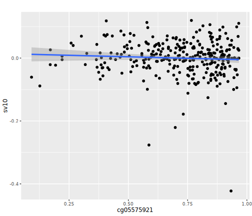

## QQ plots

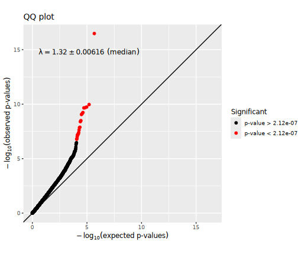

## Manhattan plots

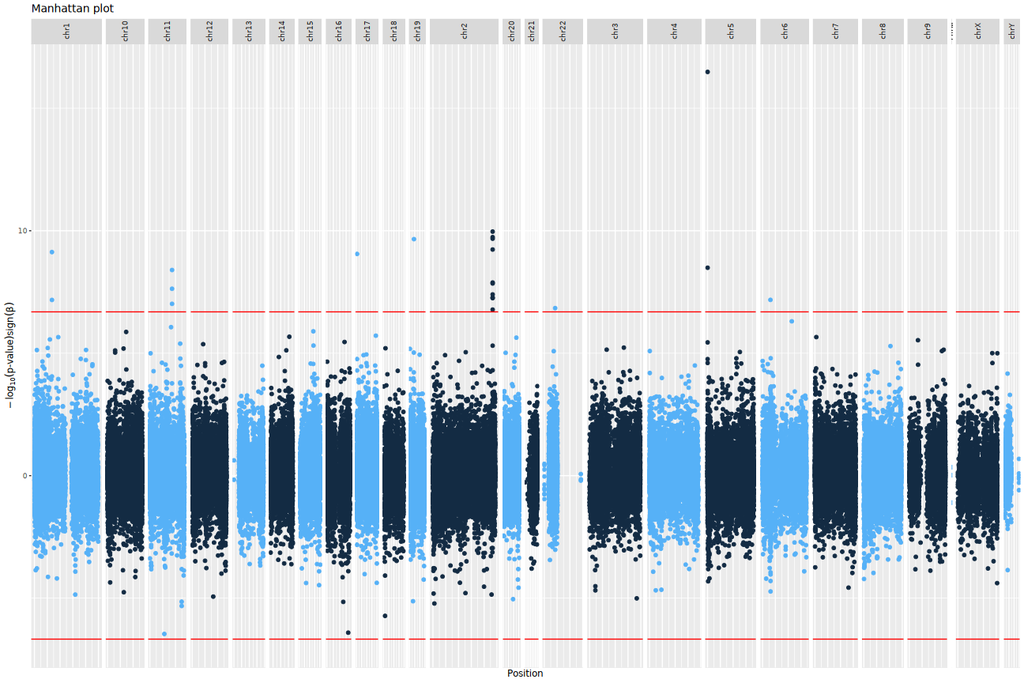

## Significant CpG sites

There were 21 CpG sites with association p-values < 2.1211427 × 10<sup>-7</sup>. These are listed in the file associations.csv.

Below are the 10 CpG sites with association p-values < 1.3043264 × 10<sup>-8</sup> in the regression model.

|  | chromosome | position | estimate | p.value | p.adjust |
| --- | --- | --- | --- | --- | --- |
| cg04284205 | chr2 | 233284296 | 0.3097298 | 0 | 0.0001378 |
| cg04284215 | chr2 | 233284427 | 0.3100411 | 0 | 0.0000497 |
| cg25648203 | chr5 | 395444 | 0.1796893 | 0 | 0.0007642 |
| cg24015091 | chr17 | 2078525 | 0.2562967 | 0 | 0.0002089 |
| cg17087741 | chr2 | 233283010 | 0.2048476 | 0 | 0.0000431 |
| cg23576855 | chr5 | 373299 | 0.5219243 | 0 | 0.0000000 |
| cg14391737 | chr11 | 86513429 | 0.2772321 | 0 | 0.0009469 |
| cg03636183 | chr19 | 17000585 | 0.2200495 | 0 | 0.0000519 |
| cg21566642 | chr2 | 233284661 | 0.2685262 | 0 | 0.0000255 |
| cg25189904 | chr1 | 68299493 | 0.2999148 | 0 | 0.0001753 |

Plots of these sites follow, one for each covariate set. “p[lm]” denotes the p-value obtained using a linear model and “p[beta]” the p-value obtained using beta regression.

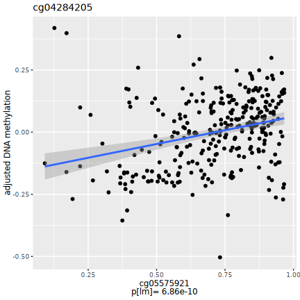

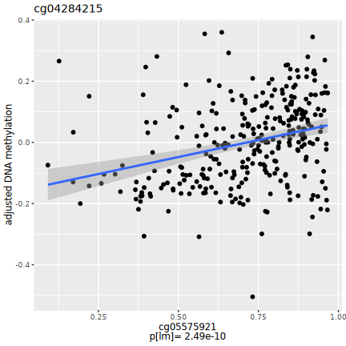

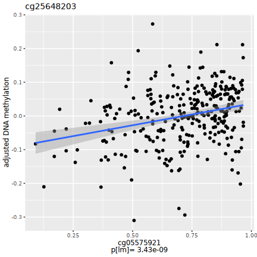

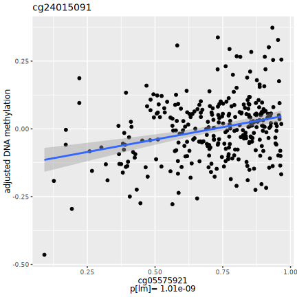

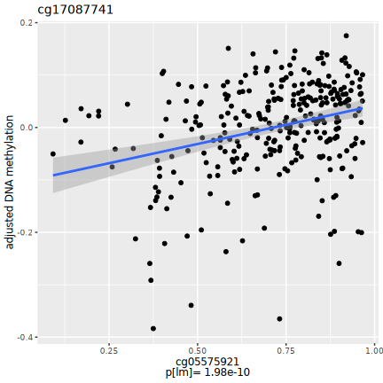

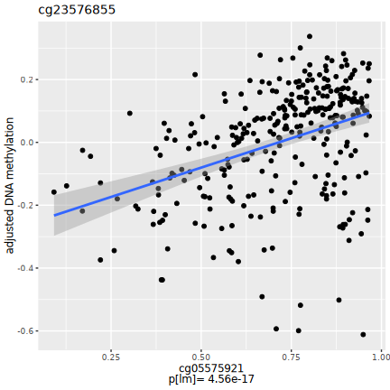

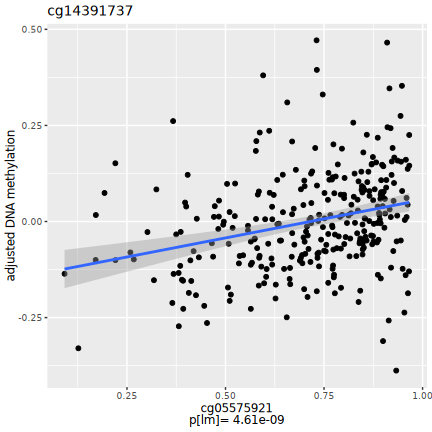

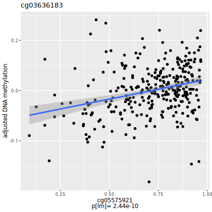

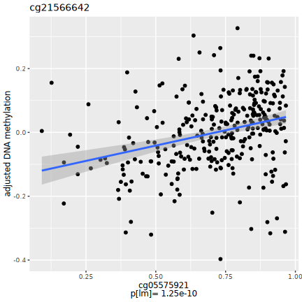

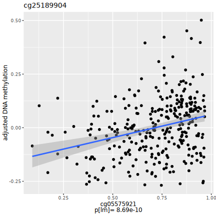

## Selected CpG sites

Number of CpG sites selected: 0.

| chromosome | position | estimate | p.value | p.adjust |
| --- | --- | --- | --- | --- |